# Inference of microbial ecological networks

# Microbial Correlation networks at genus level.

## install SpiecEasi

For more information check:

[Sparse and Compositionally Robust Inference of Microbial Ecological Networks](http://journals.plos.org/ploscompbiol/article?id=10.1371/journal.pcbi.1004226)

[Package website](https://github.com/zdk123/SpiecEasi)

[Correlation detection strategies in microbial data sets vary widely in sensitivity and precision](http://www.nature.com/ismej/journal/v10/n7/full/ismej2015235a.html)

```r
# library(devtools)
# install_github("zdk123/SpiecEasi")
# library(SpiecEasi)

# Other packages you need to install are
# install.packages("igraph")

# install.packages("intergraph")
# install.packages("GGally")
# devtools::install_github("briatte/ggnet")
#
# install.packages("network")

# install.packages("ggnetwork")
```

# Loading required packages

```r
#Load the required packages
library(ggplot2)
library(ape)
library(plyr)
library(vegan)
library(Biostrings)
library(RColorBrewer)
library(reshape2)
library(scales)
library(data.table)
library(microbiome)
library(dplyr)
library(phyloseq)
library(plotly) #for interactive plots
library(DT) #for interactive tables
library(Rcpp)
library(SpiecEasi)
library(igraph)
library(qgraph)
library(intergraph)
library(ggnet)
library(network)
library(ggnetwork)
```

For this example, will use the data made available through microbiome package. Data set from [Halfvarson et al. Nature Microbiology 2, 2017](http://www.nature.com/articles/nmicrobiol20174) characterizes longitudinal fluctuations of human intestinal microbiota in Inflammatory bowel disease (IBD) subjects and compare it with those of healthy individuals. The authors use Illumina HiSeq 2000 for the V4 region with 515F/806RBC. This data was downloaded from [Qiita](https://qiita.ucsd.edu/study/description/1629) and the Qiita study ID is 1629.

The data is already in phyloseq format. I will show how to load it and do the analysis. For your analysis, you will use the phyloseq object you created using the main tutorial.

```r
# setwd("D:/path/to/your/folder")
# Example of how to set the working directory
# setwd("N:/MOLECO/Sudarshan/NG_Tax_Phyloseq")

# remember the path in windows is given as "\" however for R it has to be changed to "/".
```

# Load data

We will now load the data. If you have your own phyloseq object ready then procceed to the next code.

```r
data("DynamicsIBD")
ibd <- DynamicsIBD
print(ibd)
```

```
## phyloseq-class experiment-level object
## otu_table()   OTU Table:         [ 10996 taxa and 683 samples ]
## sample_data() Sample Data:       [ 683 samples by 32 sample variables ]
## tax_table()   Taxonomy Table:    [ 10996 taxa by 7 taxonomic ranks ]
```

# Preparing the data for analysis

We will first repalce the rank names and make it right. Do not use the the phyloseq object created using format_phyloseq function. There can be inconsistancies. We only need to change the rank names as follows.

```r
colnames(tax_table(ibd)) <- c("Domain", "Phylum", "Class", "Order", "Family", "Genus", "Species")
```

We will subset the data to include only healthy microbial network.

```r
ibd.hc <- subset_samples(ibd, ibd_subtype== "HC")
sort(sample_sums(ibd.hc)) # there are few sample with low read numbers. We remove them and keep only those with atleast 2035 reads
```

```
## 1629.SubjectIBD723 1629.SubjectIBD718 1629.SubjectIBD639
##                 86                 94                132
## 1629.SubjectIBD659 1629.SubjectIBD657 1629.SubjectIBD599
##                156               2035               4191
## 1629.SubjectIBD541 1629.SubjectIBD537 1629.SubjectIBD498
##              42039              45433              69609
## 1629.SubjectIBD497 1629.SubjectIBD512 1629.SubjectIBD542
##              71206              97896              99168
## 1629.SubjectIBD520 1629.SubjectIBD514 1629.SubjectIBD543
##             102617             115924             121032
## 1629.SubjectIBD487 1629.SubjectIBD513 1629.SubjectIBD504
##             152605             155576             163470
## 1629.SubjectIBD540 1629.SubjectIBD508 1629.SubjectIBD526
##             173759             176568             177838
## 1629.SubjectIBD626 1629.SubjectIBD521 1629.SubjectIBD532
##             178991             183660             188810
## 1629.SubjectIBD486 1629.SubjectIBD510 1629.SubjectIBD536
##             199751             208821             212565
## 1629.SubjectIBD503 1629.SubjectIBD518 1629.SubjectIBD528
##             215403             220180             244097
## 1629.SubjectIBD482 1629.SubjectIBD519 1629.SubjectIBD534
##             247863             248512             250575
## 1629.SubjectIBD522 1629.SubjectIBD496 1629.SubjectIBD524
##             251738             257380             263000
## 1629.SubjectIBD506 1629.SubjectIBD535 1629.SubjectIBD525
##             269081             280067             282277
## 1629.SubjectIBD505 1629.SubjectIBD527 1629.SubjectIBD538
##             300940             321485             322440
## 1629.SubjectIBD483 1629.SubjectIBD511 1629.SubjectIBD500
##             328343             339315             341547
## 1629.SubjectIBD484 1629.SubjectIBD499 1629.SubjectIBD488
##             354760             366440             394418
## 1629.SubjectIBD515 1629.SubjectIBD495 1629.SubjectIBD509
##             422306             447418             495918
## 1629.SubjectIBD516 1629.SubjectIBD507 1629.SubjectIBD485
##             506480             584439             596606
## 1629.SubjectIBD481 1629.SubjectIBD539 1629.SubjectIBD501
##             633541             669527             692202
## 1629.SubjectIBD523 1629.SubjectIBD533 1629.SubjectIBD640
##             849434             901037             922567
## 1629.SubjectIBD517 1629.SubjectIBD502
##            2013700            2055353
```

Remove the low samples with very low reads

```r
set.seed(439876) # for reproducibility
ibd.hc.r <- rarefy_even_depth(ibd.hc, sample.size = 2035)
```

```
## You set `rngseed` to FALSE. Make sure you've set & recorded
##  the random seed of your session for reproducibility.
## See `?set.seed`
```

```
## ...
```

```
## 4 samples removedbecause they contained fewer reads than `sample.size`.
```

```
## Up to first five removed samples are:
```

```
## 1629.SubjectIBD6591629.SubjectIBD7181629.SubjectIBD6391629.SubjectIBD723
```

```
## ...
```

```
## 9276OTUs were removed because they are no longer
## present in any sample after random subsampling
```

```
## ...
```

Merge the samples at genus level

```r
ibd.hc.g <- tax_glom(ibd.hc.r, "Genus") #Merge at genus level.
print(ibd.hc.g)
```

```
## phyloseq-class experiment-level object
## otu_table()   OTU Table:         [ 124 taxa and 58 samples ]
## sample_data() Sample Data:       [ 58 samples by 32 sample variables ]
## tax_table()   Taxonomy Table:    [ 124 taxa by 7 taxonomic ranks ]
```

# Default function from SpiecEasi

Kindly run the following codes for getting edge values with positive and negative correlations.

```r
#' get opt merge
#'
#' Get the optimal merge matrix StARS is run.
#'
getOptMerge <- function(est) {
    if (class(est) == "select" && est$criterion == "stars") {
        return(est$merge[[est$opt.index]])
    } else
        stop("Run spiec-easi with criterion=\"stars\"")

}


getOptBeta <- function(est) {
    if (class(est) == "select" && est$method == "mb") {
        return(est$beta[[est$opt.index]])
    } else
        stop("Run spiec-easi with method=\"mb\"")
}

#' sym beta
#' Symmetrize a beta (coefficient) matrix, ie. selected from MB neighborhood selection
#'
symBeta <- function(beta, mode='ave') {
    if (mode=='ave') {
        symbeta <- (beta+t(beta))/2
   } else if (mode == "maxabs") {
        upt <- Matrix::triu(beta)
        lot <- t(Matrix::tril(beta))
        suppressMessages(maxt <- pmax(abs(upt), abs(lot)))
        uptind <- Matrix::which(maxt == abs(upt))
        lotind <- Matrix::which(maxt == abs(lot))
        if (length(uptind != 0)) maxt[uptind] <- maxt[uptind]*sign(upt[uptind])
        if (length(lotind != 0)) maxt[lotind] <- maxt[lotind]*sign(lot[lotind])
        symbeta <-  maxt + t(maxt)
    } else if (mode == "upper") {
        upt <- Matrix::triu(beta)
        symbeta <-  upt + t(upt)
    } else if (mode == "lower") {
        lot <- Matrix::tril(beta)
        symbeta <- lot + t(lot)
    } else
        stop ("mode not recognized")
    as(symbeta, 'symmetricMatrix')
}
```

Check the genus names

```r
datatable(tax_table(ibd.hc.g))
```

|  | Domain | Phylum | Class | Order | Family | Genus | Species |
| --- | --- | --- | --- | --- | --- | --- | --- |
| 4465907 | k__Bacteria | p__Firmicutes | c__Clostridia | o__Clostridiales | f__Lachnospiraceae | g__Blautia |  |
| 248902 | k__Bacteria | p__Firmicutes | c__Bacilli | o__Turicibacterales | f__Turicibacteraceae | g__Turicibacter |  |
| 4409730 | k__Bacteria | p__Firmicutes | c__Clostridia | o__Clostridiales | f__Peptostreptococcaceae | g__ |  |
| 4472202 | k__Bacteria | p__Firmicutes | c__Clostridia | o__Clostridiales | f__Lachnospiraceae | g__[Ruminococcus] |  |
| 300662 | k__Bacteria | p__Firmicutes | c__Clostridia | o__Clostridiales | f__Clostridiaceae | g__Sarcina |  |
| 4468965 | k__Bacteria | p__Proteobacteria | c__Alphaproteobacteria | o__Rickettsiales | f__mitochondria | g__Gyrocarpus |  |
| 3757809 | k__Bacteria | p__Bacteroidetes | c__Bacteroidia | o__Bacteroidales | f__Porphyromonadaceae | g__Dysgonomonas |  |
| 52166 | k__Bacteria | p__Firmicutes | c__Clostridia | o__Clostridiales | f__Veillonellaceae | g__Megasphaera |  |
| 4457438 | k__Bacteria | p__Firmicutes | c__Clostridia | o__Clostridiales | f__Lachnospiraceae | g__ |  |
| 4481861 | k__Bacteria | p__Actinobacteria | c__Actinobacteria | o__Bifidobacteriales | f__Bifidobacteriaceae | g__ |  |

[output cut: 114 more lines]

There is missing information.

```r
ibd.hc.g <- format_phyloseq(ibd.hc.g)

datatable(tax_table(ibd.hc.g))
```

|  | Domain | Phylum | Class | Order | Family | Genus | Species |
| --- | --- | --- | --- | --- | --- | --- | --- |
| 4465907 | Bacteria | Firmicutes | Clostridia | Clostridiales | Lachnospiraceae | Blautia |  |
| 248902 | Bacteria | Firmicutes | Bacilli | Turicibacterales | Turicibacteraceae | Turicibacter |  |
| 4409730 | Bacteria | Firmicutes | Clostridia | Clostridiales | Peptostreptococcaceae | f__Peptostreptococcaceae_4409730 |  |
| 4472202 | Bacteria | Firmicutes | Clostridia | Clostridiales | Lachnospiraceae | [Ruminococcus] |  |
| 300662 | Bacteria | Firmicutes | Clostridia | Clostridiales | Clostridiaceae | Sarcina |  |
| 4468965 | Bacteria | Proteobacteria | Alphaproteobacteria | Rickettsiales | mitochondria | Gyrocarpus |  |
| 3757809 | Bacteria | Bacteroidetes | Bacteroidia | Bacteroidales | Porphyromonadaceae | Dysgonomonas |  |
| 52166 | Bacteria | Firmicutes | Clostridia | Clostridiales | Veillonellaceae | Megasphaera |  |
| 4457438 | Bacteria | Firmicutes | Clostridia | Clostridiales | Lachnospiraceae | f__Lachnospiraceae_4457438 |  |
| 4481861 | Bacteria | Actinobacteria | Actinobacteria | Bifidobacteriales | Bifidobacteriaceae | f__Bifidobacteriaceae_4481861 |  |

[output cut: 114 more lines]

Now the information of best classification and OTU id is available.

```r
otu.c <- t(otu_table(ibd.hc.g)@.Data) #extract the otu table from phyloseq object
tax.c <- as.data.frame(tax_table(ibd.hc.g)@.Data)#extract the taxonomy information
head(tax.c)
```

```
##           Domain         Phylum               Class            Order
## 4465907 Bacteria     Firmicutes          Clostridia    Clostridiales
## 248902  Bacteria     Firmicutes             Bacilli Turicibacterales
## 4409730 Bacteria     Firmicutes          Clostridia    Clostridiales
## 4472202 Bacteria     Firmicutes          Clostridia    Clostridiales
## 300662  Bacteria     Firmicutes          Clostridia    Clostridiales
## 4468965 Bacteria Proteobacteria Alphaproteobacteria    Rickettsiales
##                        Family                            Genus Species
## 4465907       Lachnospiraceae                          Blautia    <NA>
## 248902      Turicibacteraceae                     Turicibacter    <NA>
## 4409730 Peptostreptococcaceae f__Peptostreptococcaceae_4409730    <NA>
## 4472202       Lachnospiraceae                   [Ruminococcus]    <NA>
## 300662         Clostridiaceae                          Sarcina    <NA>
## 4468965          mitochondria                       Gyrocarpus    <NA>
```

```r
meta.c <- sample_data(ibd.hc.g) #option meta-data if you want to map other variables

colnames(otu.c) <- tax.c$Genus#don't do this if you want only otu names in the #network
```

# SPIEC-EASI network reconstruction

This is a slow step and depending on the number of Genera, time will vary from few minutes to hours.

```r
# In practice, use more repetitions
set.seed(12534)
net.c <- spiec.easi(otu.c, method='mb', icov.select.params=list(rep.num=50))
```

```
## Normalizing/clr transformation of data with pseudocount ...
```

```
## Inverse Covariance Estimation with mb ...
```

```
## Model selection with stars ...
```

```
## Done!
```

```r
#please use more numebr of rep.num (99 or 999) the paraemters
```

# Create graph object

```r
n.c <- symBeta(getOptBeta(net.c))

colnames(n.c) <- rownames(n.c) <- colnames(otu.c)#you can remove this

vsize <- log2(apply(otu.c, 2, mean))# value we may or may not be used as vertex.attribute

ibd.ig <- graph.adjacency(n.c, mode='undirected', add.rownames = TRUE, weighted = TRUE)

ibd.ig # we can see all the attributes and weights
```

```
## IGRAPH UNW- 124 197 --
## + attr: name (v/c), TRUE (v/c), weight (e/n)
## + edges (vertex names):
## [1] Blautia                         --f__Lachnospiraceae_4457438
## [2] Blautia                         --02d06
## [3] Blautia                         --f__Erysipelotrichaceae_4468891
## [4] Blautia                         --Dorea
## [5] Blautia                         --Adlercreutzia
## [6] Blautia                         --Coprococcus
## [7] Turicibacter                    --f__Clostridiaceae_4482516
## [8] f__Peptostreptococcaceae_4409730--f__Clostridiaceae_4482516
## + ... omitted several edges
```

```r
write_graph(ibd.ig, "ibd_igraph.gml", "gml") # you can open this in gelphi software
```

Assign color based on weights of correlation

```r
#now color the edges based on their values
E(ibd.ig)[weight > 0]$color<-"green" #positive values
E(ibd.ig)[weight < 0]$color<-"red"   #negative values
```

# Set layout and plot simple network

More info on [igraph layouts](http://igraph.org/c/doc/igraph-Layout.html)

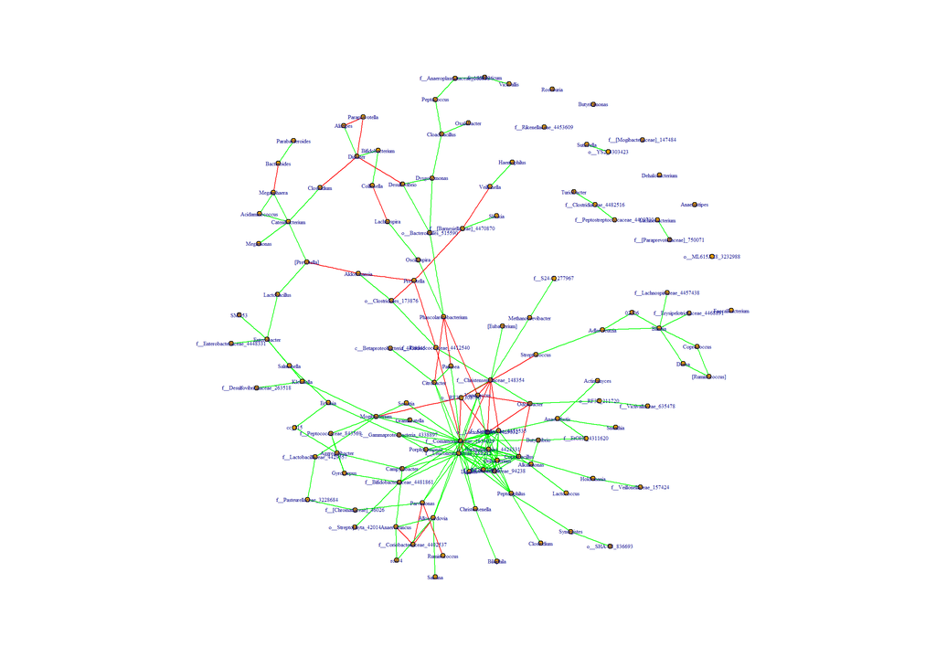

```r
#set layout
coords.ibd.ig = layout_with_fr(ibd.ig)

plot(ibd.ig, layout=coords.ibd.ig, vertex.size = 2, vertex.label.cex = 0.5)
```

convert data for better plotting.

```r
hc.net <- asNetwork(ibd.ig)
```

# Ggnet plot

## set edge attributes

```r
set.edge.attribute(hc.net, "color", ifelse(hc.net %e% "weight" > 0, "green", "red"))
```

## Coloring and node size

Color the nodes based on Phylum affiliation.

Set the node size to log2 mean abundance.

```r
phyla <- map_levels(colnames(otu.c), from = "Genus", to = "Phylum", tax_table(ibd.hc.g))
hc.net %v% "Phylum" <- phyla
hc.net %v% "nodesize" <- vsize

mycolors <- scale_color_manual(values = c("#a6cee3", "#1f78b4", "#b2df8a", "#33a02c","#fb9a99","#e31a1c","#fdbf6f","#ff7f00","#cab2d6","#6a3d9a","#ffff99","#b15928"))
```

# Inferred microbial ecological networks

```r
p1 <- ggnet2(hc.net, node.color = "Phylum", label = TRUE, node.size = "nodesize", size.legend = NULL,label.size = 4, edge.color = "color") +  guides(size = FALSE) + mycolors + ggtitle("Healthy Network")
```

```
## sna: Tools for Social Network Analysis
## Version 2.4 created on 2016-07-23.
## copyright (c) 2005, Carter T. Butts, University of California-Irvine
##  For citation information, type citation("sna").
##  Type help(package="sna") to get started.
```

```
## 'colour', which will replace the existing scale.
```

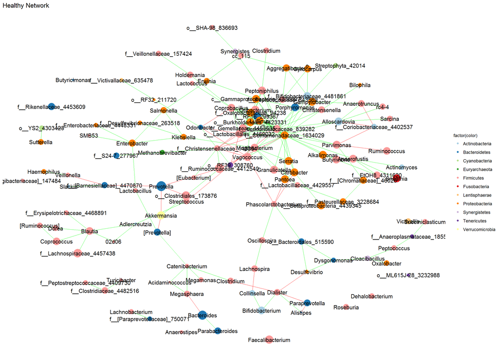

```r
print(p1)
```

```r
ggsave("Healthy_network.pdf", height = 8, width = 12)
```

You can play around according to your research question.

# Modularity in ecological networks

For information on different algorithms check [igraph manual](http://igraph.org/r/doc/modularity.igraph.html)

```r
ibd.comm <- ibd.ig
ibd.louvain <- cluster_louvain(ibd.comm, weights = NA)

print(ibd.louvain)
```

```
## IGRAPH clustering multi level, groups: 22, mod: 0.61
## + groups:
##   $`1`
##   [1] "Roseburia"
##
##   $`2`
##   [1] "Dehalobacterium"
##
##   $`3`
##   [1] "Anaerostipes"
##
##   $`4`
##   + ... omitted several groups/vertices
```

We can see that there were 22 groups detected and the modularity of the network is 0.61. " Modularity >0.4 indicates that the partition produced by the modularity algorithm can be used to detect distinct communities within the network. It indicates that there are nodes in the network that are more densely connected between each other than with the rest of the network and that their density is noticeably higher than the graph’s average (Newman, 2006)."

Network properties can be used to understand potential ecological realtions. Example [Dynamics of bacterial community succession in a salt marsh chronosequence: evidences for temporal niche partitioning](http://www.nature.com/ismej/journal/v8/n10/full/ismej201454a.html)

[Marine bacterial, archaeal and protistan association networks reveal ecological linkages](http://www.nature.com/ismej/journal/v5/n9/full/ismej201124a.html)

For more details check the article by [Newman 2006](http://www.pnas.org/content/103/23/8577)

```r
# simple plot

V(ibd.comm)$community <- ibd.louvain$membership
pdf("ibd_healthy_modularity.pdf", height = 14, width = 16)
plot(ibd.comm, vertex.color=V(ibd.comm)$community, vertex.label.cex = 0.5, vertex.size = 5, asp = 0.9)
dev.off()
```

# GGnet plot for Modularity detection

```r
ibd.net2 <- asNetwork(ibd.comm)

otu.c1 <- t(otu_table(ibd.hc.g)@.Data)

tax.c1 <- as.data.frame(tax_table(ibd.hc.g)@.Data)

colnames(otu.c1) <- tax.c1$Genus

vsize <- log2(apply(otu.c1, 2, mean))

ibd.net2 %v% "nodesize" <- vsize


# We need to set Palette
colourCount = length(unique(V(ibd.comm)$community))

getPalette = colorRampPalette(brewer.pal(11, "Paired"))


p2 <- ggnet2(ibd.net2, node.color = "community", label = TRUE, node.size = "nodesize", label.size = 4, edge.color = "grey") + guides(size = FALSE) + scale_color_manual(values = getPalette(colourCount))
```

```
## 'colour', which will replace the existing scale.
```

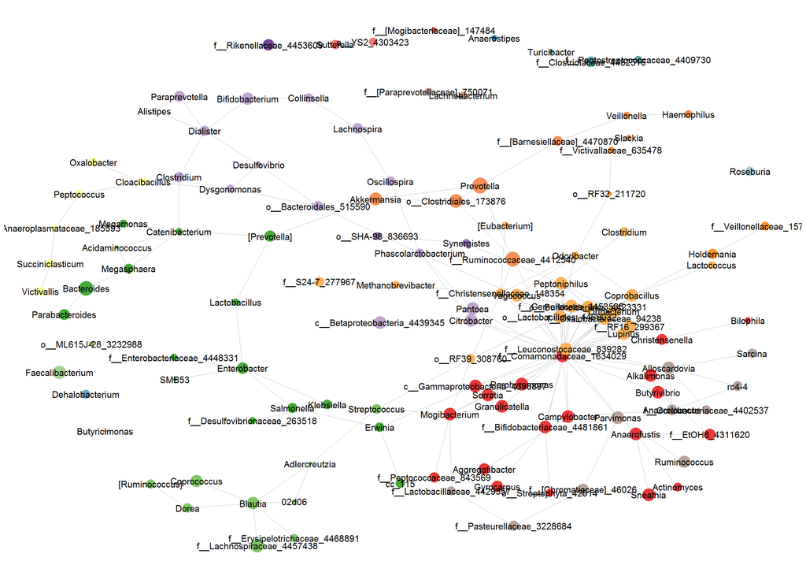

```r
print(p2)
```

```r
ggsave("healthy_modularity_network.pdf", height = 8, width = 10) #still could not manage to get the legends. If you manage please let me know.
```

sudarshan.shetty@wur.nl

2017-03-24